# project: Communicate Data Findings - Video Game Sales dataset

# Preliminary Wrangling

> In this project I will use Video Game Sales dataset which collected from Kaggle website. The dataset consistes of information about more than 10000 Video Games.

```python
# import packages
import numpy as np
import pandas as pd
import matplotlib.pyplot as plt
import seaborn as sb

%matplotlib inline
```

```python
# load the dataset
df = pd.read_csv('vgsales.csv')
# print first five rows
df.head()
```

|  | Rank | Name | Platform | Year | Genre | Publisher | NA_Sales | EU_Sales | JP_Sales | Other_Sales | Global_Sales |
| --- | --- | --- | --- | --- | --- | --- | --- | --- | --- | --- | --- |
| 0 | 1 | Wii Sports | Wii | 2006.0 | Sports | Nintendo | 41.49 | 29.02 | 3.77 | 8.46 | 82.74 |
| 1 | 2 | Super Mario Bros. | NES | 1985.0 | Platform | Nintendo | 29.08 | 3.58 | 6.81 | 0.77 | 40.24 |
| 2 | 3 | Mario Kart Wii | Wii | 2008.0 | Racing | Nintendo | 15.85 | 12.88 | 3.79 | 3.31 | 35.82 |
| 3 | 4 | Wii Sports Resort | Wii | 2009.0 | Sports | Nintendo | 15.75 | 11.01 | 3.28 | 2.96 | 33.00 |
| 4 | 5 | Pokemon Red/Pokemon Blue | GB | 1996.0 | Role-Playing | Nintendo | 11.27 | 8.89 | 10.22 | 1.00 | 31.37 |

```python
# high-level overview of data shape and composition
print(df.shape)
print(df.dtypes)
print(df.head(10))
```

[output not shown]

```python
# descriptive statistics for numeric variables
df.describe()
```

|  | Rank | Year | NA_Sales | EU_Sales | JP_Sales | Other_Sales | Global_Sales |
| --- | --- | --- | --- | --- | --- | --- | --- |
| count | 16598.000000 | 16327.000000 | 16598.000000 | 16598.000000 | 16598.000000 | 16598.000000 | 16598.000000 |
| mean | 8300.605254 | 2006.406443 | 0.264667 | 0.146652 | 0.077782 | 0.048063 | 0.537441 |
| std | 4791.853933 | 5.828981 | 0.816683 | 0.505351 | 0.309291 | 0.188588 | 1.555028 |
| min | 1.000000 | 1980.000000 | 0.000000 | 0.000000 | 0.000000 | 0.000000 | 0.010000 |
| 25% | 4151.250000 | 2003.000000 | 0.000000 | 0.000000 | 0.000000 | 0.000000 | 0.060000 |
| 50% | 8300.500000 | 2007.000000 | 0.080000 | 0.020000 | 0.000000 | 0.010000 | 0.170000 |
| 75% | 12449.750000 | 2010.000000 | 0.240000 | 0.110000 | 0.040000 | 0.040000 | 0.470000 |
| max | 16600.000000 | 2020.000000 | 41.490000 | 29.020000 | 10.220000 | 10.570000 | 82.740000 |

```python
# show a summary of the dataset
df.info()
```

```
<class 'pandas.core.frame.DataFrame'>
RangeIndex: 16598 entries, 0 to 16597
Data columns (total 11 columns):
 #   Column        Non-Null Count  Dtype
---  ------        --------------  -----
 0   Rank          16598 non-null  int64
 1   Name          16598 non-null  object
 2   Platform      16598 non-null  object
 3   Year          16327 non-null  float64
 4   Genre         16598 non-null  object
 5   Publisher     16540 non-null  object
 6   NA_Sales      16598 non-null  float64
 7   EU_Sales      16598 non-null  float64
 8   JP_Sales      16598 non-null  float64
 9   Other_Sales   16598 non-null  float64
 10  Global_Sales  16598 non-null  float64
dtypes: float64(6), int64(1), object(4)
memory usage: 1.4+ MB
```

```python
# drop the rows with missing values
df.dropna(inplace=True)
df.info()
```

```
<class 'pandas.core.frame.DataFrame'>
Int64Index: 16291 entries, 0 to 16597
Data columns (total 11 columns):
 #   Column        Non-Null Count  Dtype
---  ------        --------------  -----
 0   Rank          16291 non-null  int64
 1   Name          16291 non-null  object
 2   Platform      16291 non-null  object
 3   Year          16291 non-null  float64
 4   Genre         16291 non-null  object
 5   Publisher     16291 non-null  object
 6   NA_Sales      16291 non-null  float64
 7   EU_Sales      16291 non-null  float64
 8   JP_Sales      16291 non-null  float64
 9   Other_Sales   16291 non-null  float64
 10  Global_Sales  16291 non-null  float64
dtypes: float64(6), int64(1), object(4)
memory usage: 1.5+ MB
```

```python
# check for duplicated rows
df.duplicated().sum()
```

```
0
```

```python
df.shape
```

```
(16291, 11)
```

```python
# change the data type
df['Year'] = df.Year.astype(int)
```

```python
df.info()
```

```
<class 'pandas.core.frame.DataFrame'>
Int64Index: 16291 entries, 0 to 16597
Data columns (total 11 columns):
 #   Column        Non-Null Count  Dtype
---  ------        --------------  -----
 0   Rank          16291 non-null  int64
 1   Name          16291 non-null  object
 2   Platform      16291 non-null  object
 3   Year          16291 non-null  int32
 4   Genre         16291 non-null  object
 5   Publisher     16291 non-null  object
 6   NA_Sales      16291 non-null  float64
 7   EU_Sales      16291 non-null  float64
 8   JP_Sales      16291 non-null  float64
 9   Other_Sales   16291 non-null  float64
 10  Global_Sales  16291 non-null  float64
dtypes: float64(5), int32(1), int64(1), object(4)
memory usage: 1.4+ MB
```

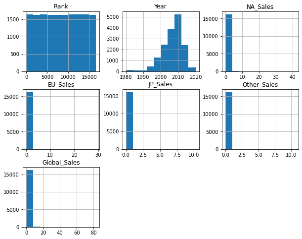

```python
# show a history about each column in the dataset
df.hist(figsize=(10,8));
```

## What is the structure of your dataset?

The Video Game Sales dataset collected from Kaggle website. The dataset consistes of information about more than 10000 Video Games, it contains 11 columns and 16291 rows. Including, name, year, genre, publisher, and global sales. The dataset contains both qualitative and quantitative types of data.

## What is/are the main feature(s) of interest in your dataset?

It is interesting that the dataset combines all the famous publisher companies around the world. Also, it provides the total sales for the top countries how interested in video games.

## What features in the dataset do you think will help support your investigation into your feature(s) of interest?

I believe that the year will have the strongest effect on the other variables such as the number of video games published and the increase in the total sales in each country.

# Univariate Exploration

In this section, I will start to do visualization for the individual variables and look at each different variable at a time.

#### What is the number of video games released among all the years?

```python
base_color = sb.color_palette()[0]
```

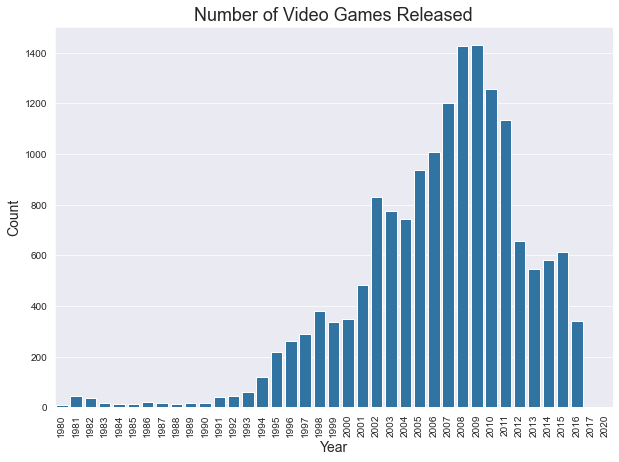

```python
# display the number of video games released by year
plt.figure(figsize=[10, 7])
sb.countplot(data=df, x='Year', color=base_color);
plt.title("Number of Video Games Released", fontsize=18)
plt.xlabel('Year', fontsize=14)
plt.ylabel("Count", fontsize=14)
# Use xticks to rotate the category labels
plt.xticks(rotation=90);
```

> The above figure shows the number of video games released from 1980 to 2020. It is clear that the number of video games started to increase year by year. However, in 2009 the number of videos games released started to decrease.

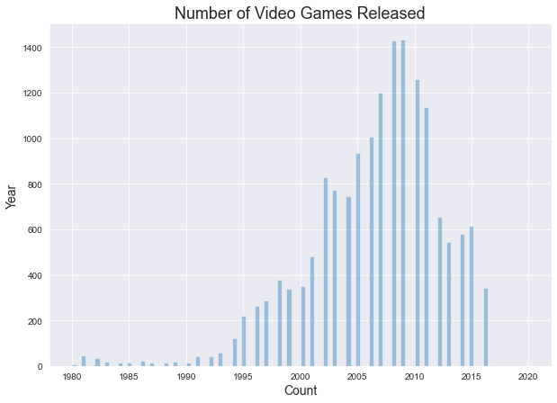

```python
# display the number of video games released by year
sb.distplot(df.Year, bins = 100,  kde=False);
plt.title("Number of Video Games Released", fontsize=18)
plt.ylabel('Year', fontsize=14);
plt.xlabel("Count", fontsize=14);
```

> The figure above also shows the number of video games released from 1980 to 2020 but with using the dist plot. It is clear that the number of video games started to increase year by year. However, in 2009 the number of videos games released started to decrease.

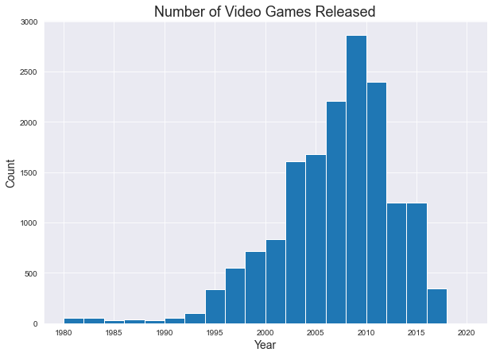

```python
# display a histogram
plt.figure(figsize=[10, 7])
plt.title("Number of Video Games Released", fontsize=18)
plt.xlabel('Year', fontsize=14)
plt.ylabel("Count", fontsize=14)
plt.hist(data = df, x = 'Year', bins = 20);
```

> The histogram above also shows the number of video games released from 1980 to 2020. It is clear that the number of video games started to increase year by year. However, in 2009 the number of videos games released started to decrease.

#### How many video games released in each platform?

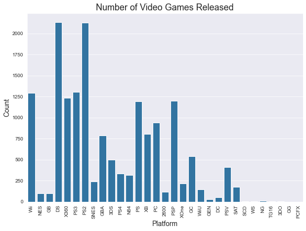

```python
# display the number of video games released by Platforms
plt.figure(figsize=[10, 7])
sb.countplot(data=df, x='Platform', color=base_color);
plt.title("Number of Video Games Released", fontsize=18)
plt.xlabel('Platform', fontsize=14)
plt.ylabel("Count", fontsize=14)
# Use xticks to rotate the category labels
plt.xticks(rotation=90);
```

> The above figure shows the number of video games released in each platform. It is clear that DS and PS2 platforms have the highest number of video games released among all other platforms.

#### How many video games released in each genre?

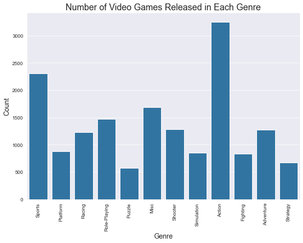

```python
# display the number of video games released by Platforms
plt.figure(figsize=[10, 7])
sb.countplot(data=df, x='Genre', color=base_color);
plt.title("Number of Video Games Released in Each Genre", fontsize=18)
plt.xlabel('Genre', fontsize=14)
plt.ylabel("Count", fontsize=14)
# Use xticks to rotate the category labels
plt.xticks(rotation=90);
```

> The count plot shows the number of video games released in each genre. It is clear that the action video games has the highest number of released. Also, there are only few puzzle video games.

## Of the features you investigated, were there any unusual distributions? Did you perform any operations on the data to tidy, adjust, or change the form of the data? If so, why did you do this?

# Bivariate Exploration

> In this section, I will look at the pairwise correlations present between features in the data.

#### What is the relationship between all variables?

```python
numeric_vars = ['Year', 'NA_Sales', 'EU_Sales', 'JP_Sales', 'Other_Sales', 'Global_Sales']
categoric_vars = ['Platform', 'Genre', 'Publisher']
```

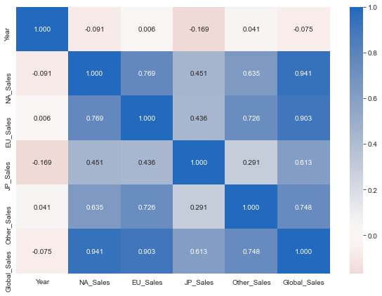

```python
# correlation plot
plt.figure(figsize = [10, 7])
sb.heatmap(df[numeric_vars].corr(), annot = True, fmt = '.3f',
           cmap = 'vlag_r', center = 0)
plt.show()
```

> The above figure shows the correlation between all the numeric variables. Also, the values were highlited with different colors based on the correlation values between each variable. For inctance, it is clear that we have a strong correlation between global sales and NA sales. Also, there are a weak correlation between JP sales and the year variable.

#### How many video games released in each genre among all the years?

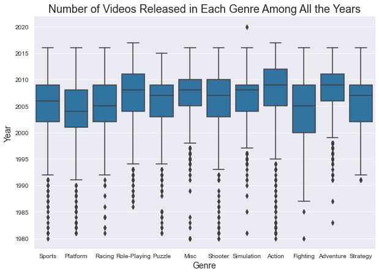

```python
# boxplot
sb.boxplot(data=df, x='Genre', y='Year', color=base_color)
plt.title("Number of Videos Released in Each Genre Among All the Years", fontsize=18)
plt.xlabel('Genre', fontsize=14)
plt.ylabel('Year', fontsize=14);
```

> The above box plot shows that the number of video games released in each gender among all the years. It shows that most of the video games released after 2000.

#### How much is the global sale in each genre?

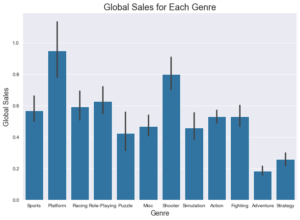

```python
# barplot
sb.barplot(data=df, x='Genre', y='Global_Sales', color=base_color);
plt.title("Global Sales for Each Genre", fontsize=18)
plt.xlabel('Genre', fontsize=14);
plt.ylabel('Global Sales', fontsize=14);
```

> The above bar plot shows the corellation between the global sales and the genre. It is clear that the platform has a higher golbal sales comparing to the other genres. However, the adventure has the lowest global sales.

## Talk about some of the relationships you observed in this part of the investigation. How did the feature(s) of interest vary with other features in the dataset?

I noticed that the global sales had a strong impact on the JP sales, EU sales, NA sales, and other sales. It shows a direct relationship between these variables since the increase in global sales results in increasing in the other variables.

## Did you observe any interesting relationships between the other features (not the main feature(s) of interest)?

# Multivariate Exploration

> In this section I will create plots of three or more variables to investigate the data even further.

#### Dose the year, genre, and global sales have an impact on each other?

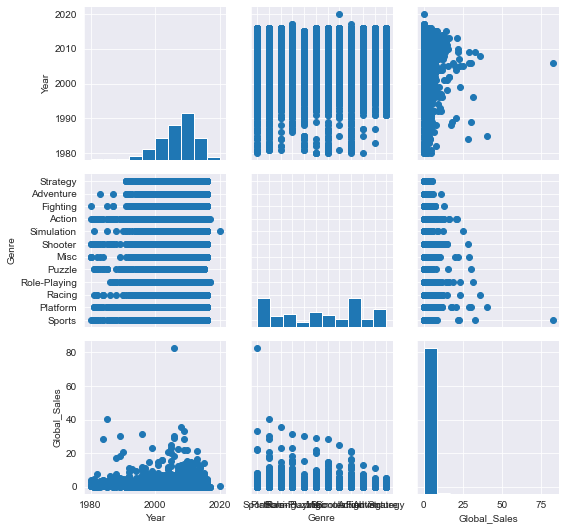

```python
g = sb.PairGrid(data = df, vars = ['Year', 'Genre', 'Global_Sales'])
g.map_diag(plt.hist)
g.map_offdiag(plt.scatter)
```

#### Dose the year, global sales, and other sales have an impact on each other?

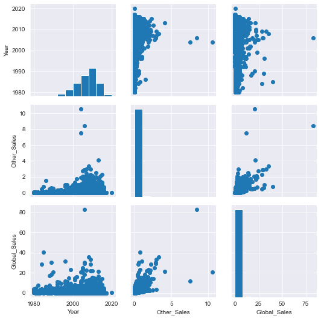

```python
g = sb.PairGrid(data = df, vars = ['Year', 'Other_Sales', 'Global_Sales'])
g.map_diag(plt.hist)
g.map_offdiag(plt.scatter)
```

#### What is the relationship between sales in Europe, Japan, and North America?

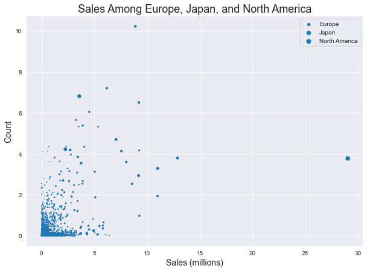

```python
plt.scatter(data = df, x = 'EU_Sales', y = 'JP_Sales', s = 'NA_Sales')

# dummy series for adding legend
sizes = [20, 40, 50]
base_color = sb.color_palette()[0]
legend_obj = []
for s in sizes:
    legend_obj.append(plt.scatter([], [], s = s, color = base_color))
plt.legend(legend_obj, ['Europe','Japan','North America'])
plt.title("Sales Among Europe, Japan, and North America", fontsize=18)
plt.xlabel('Sales (millions)', fontsize=14);
plt.ylabel('Count', fontsize=14);
```

> The above scatter plot shows the relationship between sales in Europe, Japan, and North America. It is clear from the figure that the sales were around 0 and 5 million.

## Were there any interesting or surprising interactions between features?

It is interesting how the global sales values for each genre was almost close during all years.

## Summary

- The number of video games started to increase year by year. However, in 2009 the number of videos games released started to decrease.
- DS and PS2 platforms have the highest number of video games released among all other platforms.
- The action video games has the highest number of released.
- There are only few puzzle video games.
- Most of the video games released after 2000.

## Sources

Dataset (Video Game Sales)  
https://www.kaggle.com/gregorut/videogamesales